# UD 2. Modelos avanzados de NLP. Enfoques con Deep Learning

## 1 - Word Embeddings

- 1 - One-Hot Encoding
  - 1.1 - Scikit-Learn
  - 1.2 - Keras
- 2 - Word2Vec
  - 2.1 - Entrenando un modelo propio
  - 2.2 - Utilizando el modelo Word2Vec de Google
  - 2.3 - Creando una matriz de embedding con Word2Vec o GloVe
  - 2.4 - Visualizando la similaridad de las palabras con PCA

La vectorización de palabras, es obtener un vector que, represente las características de una palabra y, se pueda dibujar o representar en un plano, de este modo, un vector a más elementos o longitud tenga más dimensiones tendrá y, por lo tanto su representación vectorial será mayor también en número de dimensiones.

El objetivo de las Word Embeddings es captar el significado, contesto y las relaciones semánticas de palabras. Esta generación de vectores se basa en la hipótesis distributiva de que las palabras que se usan cerca unas de otras suelen tener un mismo significado o parecido, por ejemplo: “Bien” y “Correcto”.

Existen diferentes formas de representar una palabra en un vector, la más sencilla de todas es a través de la codificación One-Hot, es decir, representando cada palabra en un vector binario de unos y ceros, por ejemplo:

- Supongamos las siguientes palabras en un texto.
  - Madrid, Barcelona, Sevilla, Valencia.
- Está claro que si tomamos únicamente una palabra puede ser: O bien Madrid, o bien Barcelona, o bien Sevilla o bien Valencia, pero, nunca dos palabras a la vez, dicho de otra forma, las palabras pueden expresarse como etiquetas y, la representación más correcta de las variables categóricas es llevarlas a unos y ceros, es decir, variables one-hot o Dummies.
- En el caso de las palabras, si tomamos cada palabra de un corpus y, asignamos unos y ceros en función de su orden de aparición, obtendríamos los siguientes vectores.
  - Madrid = [1, 0, 0, 0]
  - Barcelona = [0, 1, 0, 0]
  - Sevilla = [0, 0, 1, 0]
  - Valencia = [0, 0, 0, 1]

De esta forma, tendríamos la posibilidad de poder realizar operaciones entre vectores, en el caso de nuestro corpus con ciudades, podríamos llegarlos a expresar en un plano de 4 dimensiones (tantas dimensiones como palabras únicas del corpus). Análogamente, también conocemos cómo realizar operaciones sobre cadenas de texto para obtener números como Count Vectorizer o TF-IDF

## 1 - One-Hot Encoding

Para obtener la notación one-hot en Python, vamos a tomar un archivo con las 30 primeras líneas del Quijote (si se desea descargar el archivo original se puede realizar desde https://gramatica.usc.es/~gamallo/aulas/lingcomputacional/corpus/quijote-es.txt)

Leemos el archivo

```python
with open("quijote_head", encoding="utf-8") as f:
    quijote_raw = f.read()

print(quijote_raw)
```

```
Primera parte del ingenioso hidalgo don Quijote de la Mancha
Capítulo primero. Que trata de la condición y ejercicio del famoso hidalgo
don Quijote de la Mancha
En un lugar de la Mancha, de cuyo nombre no quiero acordarme, no ha mucho
tiempo que vivía un hidalgo de los de lanza en astillero, adarga antigua,
rocín flaco y galgo corredor. Una olla de algo más vaca que carnero,
salpicón las más noches, duelos y quebrantos los sábados, lantejas los
viernes, algún palomino de añadidura los domingos, consumían las tres
partes de su hacienda. El resto della concluían sayo de velarte, calzas de
velludo para las fiestas, con sus pantuflos de lo mesmo, y los días de
entresemana se honraba con su vellorí de lo más fino. Tenía en su casa una
ama que pasaba de los cuarenta, y una sobrina que no llegaba a los veinte,
y un mozo de campo y plaza, que así ensillaba el rocín como tomaba la
podadera. Frisaba la edad de nuestro hidalgo con los cincuenta años; era de
complexión recia, seco de carnes, enjuto de rostro, gran madrugador y amigo
de la caza. Quieren decir que tenía el sobrenombre de Quijada, o Quesada,
que en esto hay alguna diferencia en los autores que deste caso escriben;
aunque, por conjeturas verosímiles, se deja entender que se llamaba
Quejana. Pero esto importa poco a nuestro cuento; basta que en la narración
dél no se salga un punto de la verdad.
Es, pues, de saber que este sobredicho hidalgo, los ratos que estaba
ocioso, que eran los más del año, se daba a leer libros de caballerías, con
tanta afición y gusto, que olvidó casi de todo punto el ejercicio de la
caza, y aun la administración de su hacienda. Y llegó a tanto su curiosidad
y desatino en esto, que vendió muchas hanegas de tierra de sembradura para
comprar libros de caballerías en que leer, y así, llevó a su casa todos
cuantos pudo haber dellos; y de todos, ningunos le parecían tan bien como
los que compuso el famoso Feliciano de Silva, porque la claridad de su
prosa y aquellas entricadas razones suyas le parecían de perlas, y más
cuando llegaba a leer aquellos requiebros y cartas de desafíos, donde en
```

Limpiamos el texto con spaCy

```python
import spacy

# Cargamos textos en castellano, deshabilitando pipelines innecesarios
nlp = spacy.load("es_core_news_sm", disable=['tagger', 'parser', 'ner'])

quijote_clean = []

doc = nlp(quijote_raw)

for token in doc:
    if token.is_punct is True or token.is_stop is True or token.is_space is True:
        pass
    else:
        quijote_clean.append(token.lemma_.lower())

print(quijote_clean)
```

```
['ingenioso', 'hidalgo', 'don', 'quijote', 'mancha', 'capítulo', 'condición', 'ejercicio', 'famoso', 'hidalgo', 'don', 'quijote', 'mancha', 'lugar', 'mancha', 'cuyo', 'nombre', 'querer', 'acordarme', 'tiempo', 'vivir', 'hidalgo', 'lanza', 'astillero', 'adarga', 'antiguo', 'rocín', 'flaco', 'galgo', …
```

## 1.1 - Scikit-Learn

Una vez que tenemos el texto limpio, utilizamos del paquete preprocessing la función `OneHotEncoder` para obtener los vectores binarios

```python
import numpy as np
from sklearn import preprocessing

# Primero pasamos a array todos nuestros tokens, cada token
#  debe cargarse como una lista, para ello reshape(-1,1)
arr_text = np.array([quijote_clean]).reshape(-1, 1)
arr_text[:10]
```

```
array([['ingenioso'],
       ['hidalgo'],
       ['don'],
       ['quijote'],
       ['mancha'],
       ['capítulo'],
       ['condición'],
       ['ejercicio'],
       ['famoso'],
       ['hidalgo']], dtype='<U14')
```

```python
print(arr_text.shape) # Total de palabras
```

```
(157, 1)
```

```python
# Aplicamos el modelo OneHotEncoder
wordOneHotEncoder = preprocessing.OneHotEncoder()
line_onehot = wordOneHotEncoder.fit_transform(arr_text)
```

Una vez aplicado el modelo, podemos obtener todas las palabras únicas del mismo, es decir, el número de vectores binarios que se habrán generado

```python
wordOneHotEncoder.categories_
```

```
[array(['acordarme', 'adarga', 'administración', 'afición', 'ama', 'amigo',
        'antiguo', 'astillero', 'autor', 'añadidura', 'año', 'bastar',
        'caballería', 'calza', 'campo', 'capítulo', 'carne', 'carnero',
        'carta', 'casa', 'caso', 'caza', 'cincuenta', 'claridad',
        'complexión', 'componer', 'comprar', 'concluir', 'condición',
        'conjetura', 'consumir', 'corredor', 'cuarenta', 'cuento',
        'curiosidad', 'cuyo', 'dar', 'dejar', 'della', 'dello', 'desafío',
        'desatino', 'destar', 'diferencia', 'domingo', 'don', 'duelo',
        'dél', 'edad', 'ejercicio', 'enjuto', 'ensillar', 'entender',
        'entresemana', 'entricada', 'escribir', 'famoso', 'feliciano',
        'fiesta', 'fino', 'flaco', 'frisar', 'galgo', 'gusto', 'hacienda',
        'hanega', 'hidalgo', 'honrar', 'importar', 'ingenioso', 'lanteja',
        'lanza', 'leer', 'libro', 'llamar', 'llegar', 'llevar', 'lugar',
        'madrugador', 'mancha', 'mesmo', 'mozo', 'narración', 'noche',
        'nombre', 'ocioso', 'olla', 'olvidar', 'palomino', 'pantuflo',
        'parecer', 'parte', 'pasar', 'perla', 'plaza', 'podadera', 'prós',
        'punto', 'quebranto', 'quejana', 'querer', 'quesada', 'quijada',
        'quijote', 'rato', 'razón', 'recio', 'requiebro', 'resto', 'rocín',
        'rostro', 'salir', 'salpicón', 'sayo', 'seco', 'sembradura',
        'silva', 'sobredicho', 'sobrenombre', 'sobrina', 'sábado', 'tanto',
        'tiempo', 'tierra', 'tomar', 'vacar', 'veinte', 'velarte',
        'vellorí', 'velludo', 'vender', 'verosímil', 'viernes', 'vivir'],
       dtype='<U14')]
```

```python
print("Número de palabras únicas del corpus {}".format(len(wordOneHotEncoder.categories_[0])))
```

```
Número de palabras únicas del corpus 134
```

Vemos todos los vectores **One-Hot**

```python
line_onehot.toarray()
```

```
array([[0., 0., 0., ..., 0., 0., 0.],
       [0., 0., 0., ..., 0., 0., 0.],
       [0., 0., 0., ..., 0., 0., 0.],
       ...,
       [0., 0., 0., ..., 0., 0., 0.],
       [0., 0., 0., ..., 0., 0., 0.],
       [0., 0., 0., ..., 0., 0., 0.]])
```

Si queremos obtener el vector específico de una palabra podemos hacer lo siguiente, por ejemplo tomaremos el primer vector One-Hot

```python
line_onehot.toarray()[0]
```

```
array([0., 0., 0., 0., 0., 0., 0., 0., 0., 0., 0., 0., 0., 0., 0., 0., 0.,
       0., 0., 0., 0., 0., 0., 0., 0., 0., 0., 0., 0., 0., 0., 0., 0., 0.,
       0., 0., 0., 0., 0., 0., 0., 0., 0., 0., 0., 0., 0., 0., 0., 0., 0.,
       0., 0., 0., 0., 0., 0., 0., 0., 0., 0., 0., 0., 0., 0., 0., 0., 0.,
       0., 1., 0., 0., 0., 0., 0., 0., 0., 0., 0., 0., 0., 0., 0., 0., 0.,
       0., 0., 0., 0., 0., 0., 0., 0., 0., 0., 0., 0., 0., 0., 0., 0., 0.,
       0., 0., 0., 0., 0., 0., 0., 0., 0., 0., 0., 0., 0., 0., 0., 0., 0.,
       0., 0., 0., 0., 0., 0., 0., 0., 0., 0., 0., 0., 0., 0., 0.])
```

Obtenemos la posición del 1

```python
line_onehot.toarray()[0].argmax()
```

```
69
```

Por lo tanto, este vector representa la palabra 69

```python
wordOneHotEncoder.categories_[0][69]
```

```
'ingenioso'
```

## 1.2 - Keras

Ya que en esta unidad haremos un amplio uso de librerías de Deep Learning como **keras**, obtendremos los vectores One-Hot Encoding desde Keras, lo primero, si no tenemos instalado este paquete.

```python
# !pip install keras
```

Lo primero, cuando queremos obtener los vectores one-hot desde keras, es tokenizar las palabras, para ello, utilizaremos la función `Tokenizer` y, posteriormente obtener la matriz con dichos textos tokenizados.

```python
from keras.preprocessing.text import Tokenizer

# Generamos un objeto tokenizador
tokenizer = Tokenizer()

# Lo ajustamos a nuestros textos
tokenizer.fit_on_texts(quijote_clean)
```

```python
# Como tal, vemos que simplemente tenemos un objeto tokenizer
tokenizer
```

```
<keras_preprocessing.text.Tokenizer at 0x20cc2106588>
```

Una vez generado nuestro tokenizador, podemos obtener la matriz de vectores one-hot

```python
one_hot_matrix = tokenizer.texts_to_matrix(quijote_clean)
```

```python
one_hot_matrix
```

```
array([[0., 0., 0., ..., 0., 0., 0.],
       [0., 1., 0., ..., 0., 0., 0.],
       [0., 0., 0., ..., 0., 0., 0.],
       ...,
       [0., 0., 0., ..., 1., 0., 0.],
       [0., 0., 0., ..., 0., 1., 0.],
       [0., 0., 0., ..., 0., 0., 1.]])
```

```python
one_hot_matrix.shape # Misma longitud de tokens que con sklearn
```

```
(157, 135)
```

```python
one_hot_matrix[0] # Observamos el primer elemento
```

```
array([0., 0., 0., 0., 0., 0., 0., 0., 0., 0., 0., 0., 0., 0., 0., 0., 0.,
       0., 0., 1., 0., 0., 0., 0., 0., 0., 0., 0., 0., 0., 0., 0., 0., 0.,
       0., 0., 0., 0., 0., 0., 0., 0., 0., 0., 0., 0., 0., 0., 0., 0., 0.,
       0., 0., 0., 0., 0., 0., 0., 0., 0., 0., 0., 0., 0., 0., 0., 0., 0.,
       0., 0., 0., 0., 0., 0., 0., 0., 0., 0., 0., 0., 0., 0., 0., 0., 0.,
       0., 0., 0., 0., 0., 0., 0., 0., 0., 0., 0., 0., 0., 0., 0., 0., 0.,
       0., 0., 0., 0., 0., 0., 0., 0., 0., 0., 0., 0., 0., 0., 0., 0., 0.,
       0., 0., 0., 0., 0., 0., 0., 0., 0., 0., 0., 0., 0., 0., 0., 0.])
```

```python
np.argmax(one_hot_matrix[0])
```

```
19
```

Consultamos a qué palabra pertenece el primer vector

```python
tokenizer.index_word[np.argmax(one_hot_matrix[0])]
```

```
'ingenioso'
```

## 2 - Word2Vec

Tomamos le siguiente libro para entrenar nuestro propio modelo de Word2Vec "The Complete Works of William Shakespeare by William Shakespeare", desde la web project Gutenberg https://www.gutenberg.org/ebooks/100

```python
with open("100-0.txt", encoding="utf-8") as f:
    book = f.read()

print(book[:100])
```

```
The Project Gutenberg eBook of The Complete Works of William Shakespeare, by William Shakespeare

T
```

```python
print("Todos los caracteres del libro ", len(book))
```

```
Todos los caracteres del libro  5535508
```

## 2.1 - Entrenando un modelo propio

Para entrenar un modelo propio, aunque podríamos limpiar los textos aprovechando nuestra función anterior con spaCy, como word2vec se carga originalmente desde el paquete gensim, vamos a realizar la limpieza de los textos desde Gensim, importamos dos funciones para limpiar textos `textcleaner` y, `simple_process` para generar secuencias a través del libro, ya que como hemos podido ver, actualmente tenemos el libro cargado carácter a carácter y no secuencia a secuencia

```python
from gensim.summarization import textcleaner
from gensim.utils import simple_preprocess

def clean_and_sentences(book):
    sentences = textcleaner.split_sentences(book)
    sentence_tokens = [simple_preprocess(sentence) for sentence in sentences]
    return sentence_tokens
```

```python
# Limpiamos y generamos secuencias
clean_book = clean_and_sentences(book=book)
```

```python
clean_book[:3]
```

```
[['the',
  'project',
  'gutenberg',
  'ebook',
  'of',
  'the',
  'complete',
  'works',
  'of',
  'william',
  'shakespeare',
  'by',
  'william',
  'shakespeare'],
 ['this',
  'ebook',
  'is',
  'for',
  'the',
  'use',
  'of',
  'anyone',
  'anywhere',
  'in',
  'the',
  'united',
  'states',
  'and'],
 ['most',
  'other',
  'parts',
  'of',
  'the',
  'world',
  'at',
  'no',
  'cost',
  'and',
  'with',
  'almost',
  'no',
  'restrictions']]
```

```python
print("Longitud total de secuencias ", len(clean_book))
```

```
Longitud total de secuencias  174530
```

Una vez que tenemos todas nuestras secuencias generadas, podemos hacer uso de la función **`Word2Vec`** para entrenar un modelo propio de word embeddings basado únicamente en las obras de William Shakespeare

```python
from gensim.models import Word2Vec

# Primero, definimos el modelo de Word2Vec
model = Word2Vec(sentences = clean_book, # Conjunto se secuencias
                 size      = 100,        # Dimensión de cada vector
                 window    = 10,         # Tamaño de ventana máximo entre palabras
                 min_count = 2,          # Frecuencia mínima de veces que debe aparecer un término
                 workers   = 4           # Cores de la máquina
                )
```

```python
%%time

# Entrenamos nuestro modelo Word2Vec
model.train(clean_book,
            total_examples=len(clean_book),
            epochs=100
           )
```

```
Wall time: 1min 9s
```

```
(71469438, 92482700)
```

```python
print(f"Total de palabras entrenadas {model.corpus_total_words} ")
```

```
Total de palabras entrenadas 924827
```

Podemos obtener las palabras más similares dando un término en nuestro vocabulario

```python
model.wv.most_similar("love")
```

```
[('pity', 0.5021170377731323),
 ('hate', 0.4992274343967438),
 ('respect', 0.4880411624908447),
 ('loss', 0.4859583079814911),
 ('grief', 0.48519182205200195),
 ('madness', 0.4768259525299072),
 ('knowledge', 0.4742445647716522),
 ('modesty', 0.470663845539093),
 ('obedience', 0.46977704763412476),
 ('wisdom', 0.4663738012313843)]
```

```python
model.wv.most_similar("widow")
```

```
[('margaret', 0.41712552309036255),
 ('afeard', 0.4126680791378021),
 ('deject', 0.4037184715270996),
 ('wife', 0.38379979133605957),
 ('valeria', 0.38357365131378174),
 ('jealous', 0.38257908821105957),
 ('joined', 0.37334519624710083),
 ('volumnia', 0.36894088983535767),
 ('elinor', 0.36531949043273926),
 ('dowry', 0.3648015856742859)]
```

Por supuesto, también podemos acceder al vector resultante de cada palabra

```python
model.wv["widow"]
```

```
array([ 2.0130184 ,  0.37844113, -1.6931553 ,  0.10615541, -0.21610293,
       -0.5391924 , -1.2044643 , -1.7016275 ,  0.5739925 , -0.68992317,
       -1.5905142 ,  1.058562  , -0.4057451 , -1.3979274 ,  1.2401605 ,
       -0.23982228, -2.7968533 , -1.3804103 ,  0.7569666 , -0.19825533,
        1.1854297 , -0.9992441 , -1.6163133 , -2.9347165 ,  1.7512202 ,
        1.48955   ,  0.6115099 ,  2.8567207 , -0.568778  ,  1.3339622 ,
       -2.4801896 , -2.1112094 ,  0.2822701 , -3.0506272 ,  0.4234175 ,
        3.189351  , -0.18630013,  0.4986754 ,  0.6497523 , -0.6454083 ,
       -0.5479612 ,  0.1542317 , -0.89380676,  3.287333  , -0.58075774,
        2.2825785 , -1.3344799 ,  2.611166  , -1.8829215 ,  2.1365278 ,
       -0.882419  ,  0.6569454 ,  1.1902217 , -1.3393106 , -2.003545  ,
       -1.5323801 ,  2.0525982 , -0.3351838 ,  1.1942308 , -0.22120732,
        0.5065481 ,  1.1082803 , -0.03853266,  1.5491676 , -2.0317018 ,
       -1.8126231 , -1.1891718 ,  0.6899867 , -0.6496282 , -0.4923426 ,
       -0.98689944,  1.1380546 , -2.7245538 ,  0.20279977,  1.4794112 ,
        0.20533025,  2.5323968 ,  0.3060291 , -0.47897446,  1.1098952 ,
        1.2396145 ,  0.36618066, -0.93874586, -1.0377138 ,  0.3173019 ,
       -1.5419419 ,  0.1952201 , -0.07173035,  1.2664367 ,  0.5593015 ,
        0.46040985, -2.2103693 , -0.10046425,  0.9078047 , -0.55864465,
        0.49762428,  1.4468918 ,  1.4224427 ,  1.1199377 , -1.3908238 ],
      dtype=float32)
```

```python
model.wv["love"]
```

```
array([-2.05419946e+00,  1.11757353e-01,  3.80080827e-02, -1.26591241e+00,
       -2.07193756e+00,  2.45454288e+00,  2.96252894e+00,  3.97192448e-01,
       -1.90146118e-01, -8.80155414e-02, -1.10190117e+00,  1.10961497e+00,
        1.03830791e+00, -2.08730507e+00, -1.60024881e+00,  1.81627023e+00,
       -7.45672822e-01,  1.02175641e+00,  1.66393161e+00,  9.37912822e-01,
        4.94712770e-01,  1.29015720e+00,  4.24001902e-01, -4.27430439e+00,
       -1.11777794e+00,  2.28818226e+00,  1.25894511e+00, -5.39925635e-01,
       -1.59441280e+00,  8.62277225e-02, -2.41599584e+00,  1.14521962e-02,
       -1.72248352e+00,  1.13072026e+00, -1.22199297e+00,  1.39630210e+00,
        1.69035137e-01, -1.01359463e+00,  1.32508934e+00, -4.65792090e-01,
        1.18401480e+00,  3.69877997e-03, -2.49113131e+00,  2.20230198e+00,
        4.12194639e-01,  3.28385282e+00, -1.89495301e+00, -4.47949052e-01,
        1.89705753e+00,  9.86888468e-01,  5.28848469e-01,  9.35362518e-01,
       -5.87746084e-01,  5.37907541e-01, -5.79512477e-01,  2.19476093e-02,
       -1.17695466e-01,  1.54321849e+00, -1.02866042e+00, -1.26354194e+00,
        9.92529571e-01,  6.13301992e-01,  2.28821278e+00,  4.17581320e+00,
       -8.79969776e-01, -2.23900139e-01, -6.93653107e-01, -3.87226731e-01,
       -1.96804619e+00, -3.32309812e-01,  8.79007399e-01,  6.11990273e-01,
        1.04703140e+00,  1.24152772e-01, -1.33179677e+00,  6.19586170e-01,
       -3.55051816e-01,  4.56977487e-01,  2.72372031e+00,  8.82414639e-01,
       -7.38255441e-01,  1.33898258e+00, -1.61484468e+00,  7.26581514e-01,
       -2.02492774e-02,  7.53178537e-01,  1.53067887e-01, -1.54206872e+00,
        2.26329699e-01,  1.76778555e-01, -1.13654208e+00,  2.28272986e+00,
        1.15785885e+00,  1.08248651e+00,  6.32329643e-01,  1.04236484e-01,
       -6.31680906e-01, -1.75183785e+00, -3.00865859e-01,  2.72251248e+00],
      dtype=float32)
```

Incluso, representarlo gráficamente

```python
arr = np.array([
    model.wv["love"],
    model.wv["hate"]
]).T
```

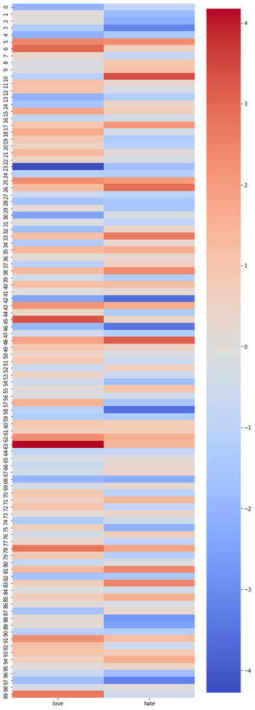

```python
import seaborn as sns
import matplotlib.pyplot as plt

fig, ax = plt.subplots(figsize=(8, 25))
sns.heatmap(arr, cmap="coolwarm", xticklabels = ["love", "hate"])
plt.show()
```

## 2.2 - Utilizando el modelo Word2Vec de Google

Como tal, entrenar un modelo propio de Word2Vec puede ser muy costoso en tiempo y, en disco (si exportamos el modelo), como tal, existen ya múltiples modelos pre-entrenados, en este caso, vamos a utilizar desde Gensim el modelo del paper https://code.google.com/archive/p/word2vec/ . En este caso, tomaremos el modelo extraido sobre Google News, que está entrenado alrededor de 100 billones de palabras, este modelo pre-entrenado, se puede descargar desde: https://drive.google.com/file/d/0B7XkCwpI5KDYNlNUTTlSS21pQmM/edit?usp=sharing

Una vez descargado el modelo, lo importamos mediante Gensim

```python
from gensim.models import KeyedVectors

filename = 'GoogleNews-vectors-negative300.bin.gz'
```

```python
%%time
model = KeyedVectors.load_word2vec_format(filename, binary=True)
```

```
Wall time: 56.6 s
```

Una vez cargado el modelo, (se necesitan mínimo 4GB RAM para cargar el archivo en Python, si no se dispone de tanta RAM, para evitar un *memory overflow* se proporcionará GloVe que es mucho menos exigente en memoria) se pueden realizar las operaciones de similaridad (internamente, se realiza Cosine Similarity)

[figure not shown]

A través de la función `most_similar` podemos tomar como palabras a sumar (positive) y las que restan como (negative)

```python
result = model.most_similar(positive=['woman', 'king'], negative=['man'], topn=1)

print(result)
```

```
[('queen', 0.7118192911148071)]
```

```python
result = model.most_similar(positive=['Italy', 'Paris'], negative=['France'])
print(result)
```

```
[('Milan', 0.7222140431404114), ('Rome', 0.7028310298919678), ('Palermo_Sicily', 0.5967570543289185), ('Italian', 0.5911272764205933), ('Tuscany', 0.563281238079071), ('Bologna', 0.5608358383178711), ('Sicily', 0.559638500213623), ('Bologna_Italy', 0.5470059514045715), ('Berna_Milan', 0.546402752399…
```

**Importante**: En caso de que, la carga de Word2Vec de fallo por memoria RAM se ofrece la siguiente solución empleando **GloVe**, para poder utilizar Glove se debe descargar el siguiente archivo. https://huggingface.co/stanfordnlp/glove/resolve/main/glove.6B.zip

Este archivo, como tal, contiene modelos pre-entrenados sobre palabras descargadas de Wikipedia (se entrenó sobre 6 billones de tokens), el archivo descargado, debe descomprimirse y, escogerse uno de los archivos con más o menos dimensionalidad, siendo el menos exigente en memoria `glove.6B.50d` y el más exigente `glove.6B.300d`. Como tal, GloVe 50D puede cargarse con menos de 1GB de RAM

```python
from gensim.models import KeyedVectors
from gensim.scripts.glove2word2vec import glove2word2vec

# Escogemos la versión más liviana.
glove_input_file = 'glove.6B/glove.6B.50d.txt'

# Tenemos que pasarlo a formato w2vec
word2vec_output_file = 'glove.6B/glove.6B.50d.txt.word2vec'
glove2word2vec(glove_input_file, word2vec_output_file)
```

```
(400001, 50)
```

```python
%%time
model = KeyedVectors.load_word2vec_format(word2vec_output_file, binary=False)
```

```
Wall time: 19.3 s
```

```python
result = model.most_similar(positive=['woman', 'king'], negative=['man'], topn=1)
print(result)
```

```
[('queen', 0.8523603677749634)]
```

```python
result = model.most_similar(positive=['italy', 'paris'], negative=['france'], topn=1)
print(result)
```

```
[('rome', 0.8465589880943298)]
```

## 2.3 - Creando una matriz de embedding con Word2Vec o GloVe

Una de las tareas que debemos realizar cuando estamos creando un modelo de clasificación basado en Deep Learning como por ejemplo una LSTM o CNN (Long Short Term Memory o Convolutional Network), para ajustar los pesos de los textos de entrenamiento, una de nuestras primeras tareas debe ser generar una **matriz de embedding** a través de la siguiente función semuestra un código que funciona tanto para Glove, Word2Vec y Fasttext que, recibe como parámetros:

- Nombre del modelo a cargar
  - word2vec
  - glove
  - fasttext
- Ruta con el fichero

El objetivo que se persigue al generar una matriz de embedding es disponer de una matriz en forma de diccionario de datos (posteriormente, para tomar las palabras de entrenamiento del corpus, es cuando se genera la matriz), en la que se tenga {"palabra_modelo" : vector}

```python
def loadEmbeddingMatrix(typeToLoad, file_dir):
        import gc

        """
        Función desarrollada para obtener una embedding matrix en forma de
         embedding index, en donde cada campo clave sea la palabra del modelo
         pre-entrenado y, cada campo valor el propio vector asociado a cada
         palabra.

         (Requiere cargar gensim.models, por ejemplo: from gensim.models import KeyedVectors)

        input:
        - typeToLoad: string. Nombre del modelo con el que se va a generar la
                      la matriz de embedding, pueden ser:
                      - glove
                      - fasttext
                      - word2vec
        - file_dir: Path con la ruta del archivo a cargar

        output
        - embedding_index (dict)

        """

        # Primero, revisamos el tipo de archivo que vamos a cargar.
        if (typeToLoad == "glove") or (typeToLoad == "fasttext"):
            EMBEDDING_FILE = file_dir

        elif typeToLoad == "word2vec":
            word2vecDict = KeyedVectors.load_word2vec_format(file_dir, binary=True)

        else:
            print("! Has incluido un modelo pre-entrenado de entrada incorrecto !")

        if(typeToLoad=="glove" or typeToLoad=="fasttext" ):
            # Diccionario para ir almacenando las palabras como campo clave:vector
            embeddings_index = dict()

            # Primero, pasamos en un dict como campo clave la palabra y como campo valor cada vector
            f = open(EMBEDDING_FILE, encoding = "utf-8")

            for line in f:
                # Separamos cada array
                values = line.split()

                # Tanto en fasttext como glove, la primera posición del vector
                #  es la palabra
                word = values[0]

                # El resto de posiciones del array son el vector en cuestión
                embeddings_index[word] = np.asarray(values[1:], dtype='float32')

            f.close()
            print('Cargados %s word vectors.' % len(embeddings_index))

        # Word2Vec
        # Glove en versión binaria desde Gensim
        else:
            # Diccionario para ir almacenando las palabras como campo clave:vector
            embeddings_index = dict()
            for word in word2vecDict.vocab:
                embeddings_index[word] = word2vecDict.word_vec(word)
            print('Cargados %s word vectors.' % len(embeddings_index))

        gc.collect()

        return embeddings_index
```

```python
%%time

filename = 'GoogleNews-vectors-negative300.bin.gz'

embedding_index = loadEmbeddingMatrix(typeToLoad     = "word2vec",
                                      file_dir       = filename)
```

```
Cargados 3000000 word vectors.
Wall time: 1min 4s
```

```python
embedding_index["king"]
```

```
array([ 1.25976562e-01,  2.97851562e-02,  8.60595703e-03,  1.39648438e-01,
       -2.56347656e-02, -3.61328125e-02,  1.11816406e-01, -1.98242188e-01,
        5.12695312e-02,  3.63281250e-01, -2.42187500e-01, -3.02734375e-01,
       -1.77734375e-01, -2.49023438e-02, -1.67968750e-01, -1.69921875e-01,
        3.46679688e-02,  5.21850586e-03,  4.63867188e-02,  1.28906250e-01,
        1.36718750e-01,  1.12792969e-01,  5.95703125e-02,  1.36718750e-01,
        1.01074219e-01, -1.76757812e-01, -2.51953125e-01,  5.98144531e-02,
        3.41796875e-01, -3.11279297e-02,  1.04492188e-01,  6.17675781e-02,
        1.24511719e-01,  4.00390625e-01, -3.22265625e-01,  8.39843750e-02,
        3.90625000e-02,  5.85937500e-03,  7.03125000e-02,  1.72851562e-01,
        1.38671875e-01, -2.31445312e-01,  2.83203125e-01,  1.42578125e-01,
        3.41796875e-01, -2.39257812e-02, -1.09863281e-01,  3.32031250e-02,
       -5.46875000e-02,  1.53198242e-02, -1.62109375e-01,  1.58203125e-01,
       -2.59765625e-01,  2.01416016e-02, -1.63085938e-01,  1.35803223e-03,
       -1.44531250e-01, -5.68847656e-02,  4.29687500e-02, -2.46582031e-02,
        1.85546875e-01,  4.47265625e-01,  9.58251953e-03,  1.31835938e-01,
        9.86328125e-02, -1.85546875e-01, -1.00097656e-01, -1.33789062e-01,
       -1.25000000e-01,  2.83203125e-01,  1.23046875e-01,  5.32226562e-02,
       -1.77734375e-01,  8.59375000e-02, -2.18505859e-02,  2.05078125e-02,
       -1.39648438e-01,  2.51464844e-02,  1.38671875e-01, -1.05468750e-01,
        1.38671875e-01,  8.88671875e-02, -7.51953125e-02, -2.13623047e-02,
        1.72851562e-01,  4.63867188e-02, -2.65625000e-01,  8.91113281e-03,
        1.49414062e-01,  3.78417969e-02,  2.38281250e-01, -1.24511719e-01,
       -2.17773438e-01, -1.81640625e-01,  2.97851562e-02,  5.71289062e-02,
       -2.89306641e-02,  1.24511719e-02,  9.66796875e-02, -2.31445312e-01,
        5.81054688e-02,  6.68945312e-02,  7.08007812e-02, -3.08593750e-01,
       -2.14843750e-01,  1.45507812e-01, -4.27734375e-01, -9.39941406e-03,
        1.54296875e-01, -7.66601562e-02,  2.89062500e-01,  2.77343750e-01,
       -4.86373901e-04, -1.36718750e-01,  3.24218750e-01, -2.46093750e-01,
       -3.03649902e-03, -2.11914062e-01,  1.25000000e-01,  2.69531250e-01,
        2.04101562e-01,  8.25195312e-02, -2.01171875e-01, -1.60156250e-01,
       -3.78417969e-02, -1.20117188e-01,  1.15234375e-01, -4.10156250e-02,
       -3.95507812e-02, -8.98437500e-02,  6.34765625e-03,  2.03125000e-01,
        1.86523438e-01,  2.73437500e-01,  6.29882812e-02,  1.41601562e-01,
       -9.81445312e-02,  1.38671875e-01,  1.82617188e-01,  1.73828125e-01,
        1.73828125e-01, -2.37304688e-01,  1.78710938e-01,  6.34765625e-02,
        2.36328125e-01, -2.08984375e-01,  8.74023438e-02, -1.66015625e-01,
       -7.91015625e-02,  2.43164062e-01, -8.88671875e-02,  1.26953125e-01,
       -2.16796875e-01, -1.73828125e-01, -3.59375000e-01, -8.25195312e-02,
       -6.49414062e-02,  5.07812500e-02,  1.35742188e-01, -7.47070312e-02,
```

[output cut: 21 more lines]

```
        1.57226562e-01, -1.14257812e-01, -2.05078125e-01,  9.91210938e-02,
        3.69140625e-01, -1.97265625e-01,  3.54003906e-02,  1.09375000e-01,
        1.31835938e-01,  1.66992188e-01,  2.35351562e-01,  1.04980469e-01,
       -4.96093750e-01, -1.64062500e-01, -1.56250000e-01, -5.22460938e-02,
        1.03027344e-01,  2.43164062e-01, -1.88476562e-01,  5.07812500e-02,
       -9.37500000e-02, -6.68945312e-02,  2.27050781e-02,  7.61718750e-02,
        2.89062500e-01,  3.10546875e-01, -5.37109375e-02,  2.28515625e-01,
        2.51464844e-02,  6.78710938e-02, -1.21093750e-01, -2.15820312e-01,
       -2.73437500e-01, -3.07617188e-02, -3.37890625e-01,  1.53320312e-01,
        2.33398438e-01, -2.08007812e-01,  3.73046875e-01,  8.20312500e-02,
        2.51953125e-01, -7.61718750e-02, -4.66308594e-02, -2.23388672e-02,
        2.99072266e-02, -5.93261719e-02, -4.66918945e-03, -2.44140625e-01,
       -2.09960938e-01, -2.87109375e-01, -4.54101562e-02, -1.77734375e-01,
       -2.79296875e-01, -8.59375000e-02,  9.13085938e-02,  2.51953125e-01],
      dtype=float32)
```

## 2.4 - Visualizando la similaridad de las palabras con PCA

Tras crear un modelo basado en vectorización de textos, con Word2vec, como tal, todos los vectores de las palabras deben estar representados en N dimensiones, por lo que si, tomamos la posición de cada dimensión obtendríamos la representación visual de cada palabra, existen ya algunos visores de este tipo como el projector de tensorflow https://projector.tensorflow.org/

En esta ocasión, vamos a realizar PCA para reducir el número de dimensiones y, poder computar visualizar las palabras de nuestro corpus entrenado con Wor2vec.

Es importante, detenerse en que, nuestra representación será en 2D, por lo que, el número de componentes principales de nuestro PCA será de 2.

```python
from sklearn.decomposition import PCA
import matplotlib.pyplot as plt

# Creamos el modelo PCA vacío para 2 componentes
pca = PCA(n_components=2)
```

```python
# Volvemos a obtener nuestro modelo basado en Word2vec sobre las obras de Shakespeare

model = Word2Vec(sentences = clean_book, # Conjunto se secuencias
                 size      = 100,        # Dimensión de cada vector
                 window    = 10,         # Tamaño de ventana máximo entre palabras
                 min_count = 2,          # Frecuencia mínima de veces que debe aparecer un término
                 workers   = 4           # Cores de la máquina
                )

model.train(clean_book,
            total_examples=len(clean_book),
            epochs=100
           )
```

```
(71469443, 92482700)
```

```python
# Ajustamos el modelo PCA a nuestro W2Vec
# (accediendo solo al vocabulario para obtener la matriz de embedding)

shak_pca = pca.fit_transform(model[model.wv.vocab])
```

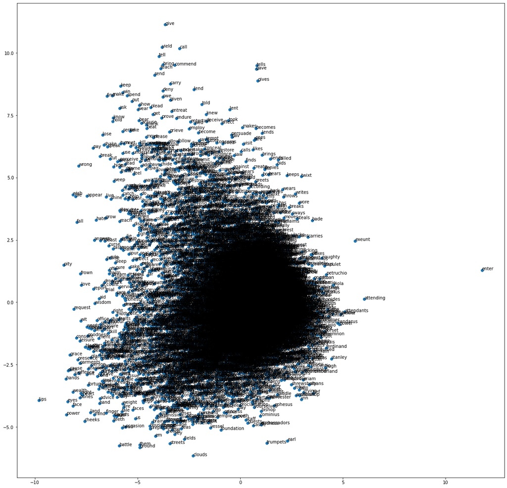

```python
fig, ax = plt.subplots(figsize = (20, 20))

ax.scatter(
    shak_pca[ :, 0], # Primer componente
    shak_pca[ :, 1]  # Segundo componente
)
# Imprimimos cada palabra
for i, palabra in enumerate(list(model.wv.vocab)):
    ax.text(shak_pca[i, 0], shak_pca[i, 1], palabra)

plt.show()
```

Probamos un modelo más reducido, con el corpus del quijote

```python
%%time

# Leemos el quijote
with open("quijote_head", encoding="utf-8") as f:
    book = f.read()

# Limpiamos los textos haciendo uso de funciones de Gensim
clean_book = clean_and_sentences(book=book)

# Creamos el modelo Wor2Vec
model = Word2Vec(sentences = clean_book, # Conjunto se secuencias
                 size      = 100,        # Dimensión de cada vector
                 window    = 10,         # Tamaño de ventana máximo entre palabras
                 min_count = 2,          # Frecuencia mínima de veces que debe aparecer un término
                 workers   = 4           # Cores de la máquina
                )

model.train(clean_book,
            total_examples=len(clean_book),
            epochs=100
           )

# Implementamos un modelo PCA
pca = PCA(n_components=2)
pca = pca.fit_transform(model[model.wv.vocab])
```

```
Wall time: 442 ms
```

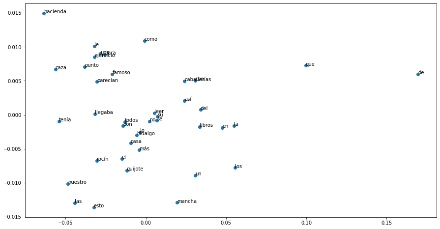

```python
fig, ax = plt.subplots(figsize = (15, 8))

ax.scatter(
    pca[ :, 0], # Primer componente
    pca[ :, 1]  # Segundo componente
)
# Imprimimos cada palabra
for i, palabra in enumerate(list(model.wv.vocab)):
    ax.text(pca[i, 0], pca[i, 1], palabra)

plt.show()
```